# Introduction to Descriptive Statistics

Rajitha M. Silva

# Topic 3: Introduction to Descriptive Statistics

This topic introduces graphical and numerical methods for understanding data. Students will learn how to use graphs and summary measures to describe patterns, compare groups, identify unusual values, and communicate results clearly in data science and business analytics.

Descriptive statistics is the first step in almost every data analysis project. Before building models or making predictions, a data analyst must understand the data.

In practice, descriptive statistics helps us answer questions such as:

- What does the data look like?
- Which values occur most often?
- Is the distribution symmetric or skewed?
- Are there unusual observations?
- How spread out are the values?
- Which group has higher or lower values?
- How can we present data clearly to decision-makers?

The purpose of this topic is to help students summarize data using suitable graphs and numerical measures.

## Why Descriptive Statistics Matters in Data Science and Business Analytics

Raw data are usually difficult to understand directly. A spreadsheet with thousands of rows may contain useful information, but that information is not immediately visible.

Descriptive statistics helps us convert raw data into meaningful summaries.

In business analytics, descriptive statistics is used in:

- customer profiling;
- sales analysis;
- market research;
- quality control;
- human resource analytics;
- financial reporting;
- operational performance monitoring;
- dashboard development.

For example, a retail company may have daily sales data for many branches. Descriptive statistics can help identify high-performing branches, low sales periods, unusual sales values, and customer purchasing patterns.

## Types of Data

Before choosing a graph or numerical summary, we must understand the type of data.

Different types of data require different methods of presentation and analysis.

### Qualitative Data

Qualitative data describe categories or labels.

Examples include:

- gender;
- payment method;
- customer segment;
- product category;
- branch location;
- satisfaction level;
- risk category.

Qualitative data are usually summarized using frequency tables, relative frequency tables, bar graphs, and pie charts.

### Quantitative Data

Quantitative data are numerical values.

Examples include:

- monthly income;
- delivery time;
- customer spending;
- age;
- number of purchases;
- exam marks;
- waiting time.

Quantitative data are usually summarized using dot plots, histograms, stem-and-leaf plots, box-and-whisker plots, and numerical measures such as mean, median, range, and interquartile range.

### Discrete Quantitative Data

Discrete quantitative data take countable values.

Examples include:

- number of complaints;
- number of children;
- number of website visits;
- number of products purchased.

### Continuous Quantitative Data

Continuous quantitative data can take any value within an interval.

Examples include:

- height;
- weight;
- income;
- time;
- temperature;
- distance.

## Frequency Tables and Relative Frequency Tables

A frequency table shows how often each value or category occurs.

A relative frequency table shows the proportion or percentage of observations in each category.

Frequency and relative frequency tables are very useful for summarizing categorical data.

### Example

Suppose a company records the preferred payment method of 100 customers.

| Payment Method | Frequency |
| --- | --- |
| Cash | 20 |
| Card | 45 |
| Bank Transfer | 15 |
| Mobile Payment | 20 |

The relative frequency is calculated as:

$$\text{Relative Frequency} =
\frac{\text{Frequency}}{\text{Total Frequency}}$$

For card payments:

$$\text{Relative Frequency} = \frac{45}{100} = 0.45$$

So, 45% of customers used card payments.

### Business Interpretation

The most common payment method is card payment. This suggests that card payment facilities are important for this company.

If mobile payment is growing over time, the company may also consider improving mobile payment options.

### Activity 3.1

A company records the delivery rating of 50 customers.

| Rating | Frequency |
| --- | --- |
| Poor | 5 |
| Fair | 10 |
| Good | 20 |
| Excellent | 15 |

Find the relative frequency for each rating.

Interpret the most common rating.

**Solution**

The total number of customers is:

$$5 + 10 + 20 + 15 = 50$$

For Poor:

$$\frac{5}{50} = 0.10$$

For Fair:

$$\frac{10}{50} = 0.20$$

For Good:

$$\frac{20}{50} = 0.40$$

For Excellent:

$$\frac{15}{50} = 0.30$$

The relative frequency table is:

| Rating | Frequency | Relative Frequency |
| --- | --- | --- |
| Poor | 5 | 0.10 |
| Fair | 10 | 0.20 |
| Good | 20 | 0.40 |
| Excellent | 15 | 0.30 |

The most common rating is Good, with a relative frequency of 0.40 or 40%.

## Bar Graphs

A bar graph is used to display categorical data.

In a bar graph, categories are shown on one axis and frequencies or percentages are shown on the other axis.

The bars are separated because the categories are distinct.

### Practical Example

Suppose a business records the number of customers by product category.

| Product Category | Number of Customers |
| --- | --- |
| Food | 120 |
| Clothing | 80 |
| Electronics | 60 |
| Books | 40 |

A bar graph can be used to compare the number of customers across product categories.

### Interpretation

The tallest bar shows the most common category.

In this example, Food has the largest number of customers.

This may suggest that food products are the strongest category for the business.

### When to Use a Bar Graph

Use a bar graph when:

- the data are categorical;
- you want to compare categories;
- the order of categories is not necessarily numerical;
- you want a simple visual summary.

### Activity 3.2

A bank records the number of customers using different banking channels.

| Banking Channel | Number of Customers |
| --- | --- |
| Branch | 150 |
| ATM | 220 |
| Mobile App | 300 |
| Internet Banking | 180 |

Which banking channel is most commonly used?

Which graph is suitable for presenting this data?

**Solution**

The most commonly used banking channel is Mobile App, because it has the highest frequency:

$$300$$

A bar graph is suitable because the data are categorical.

## Pie Charts

A pie chart is used to show how a whole is divided into parts.

Each slice of the pie represents a category. The size of the slice shows the percentage or proportion of the total.

### Practical Example

Suppose a company studies the market share of four brands.

| Brand | Market Share |
| --- | --- |
| Brand A | 40% |
| Brand B | 25% |
| Brand C | 20% |
| Brand D | 15% |

A pie chart can show how the total market is divided among the four brands.

### When to Use a Pie Chart

Use a pie chart when:

- the data are categorical;
- the categories form parts of a whole;
- the number of categories is small;
- percentages add up to 100%.

### Warning for Students

Pie charts are not always the best graph.

If there are many categories, a pie chart becomes difficult to read.

A bar graph is often clearer when comparing many categories.

### Activity 3.3

A company analyzes the source of website traffic.

| Source | Percentage |
| --- | --- |
| Search Engine | 50% |
| Social Media | 25% |
| Direct Visit | 15% |
| Email | 10% |

Is a pie chart suitable for this data?

Give a practical interpretation.

**Solution**

Yes, a pie chart is suitable because the categories form parts of a whole and the percentages add up to 100%.

The largest source of website traffic is Search Engine, with 50% of visits. This suggests that search visibility is very important for the company.

## Line Graphs

A line graph is used to show how a variable changes over time.

Line graphs are very useful in business analytics because many business data sets are time-based.

Examples include:

- monthly sales;
- daily website visits;
- weekly customer complaints;
- yearly profit;
- hourly electricity usage;
- monthly inflation rate.

### Practical Example

Suppose a shop records monthly sales.

| Month | Sales |
| --- | --- |
| January | 120000 |
| February | 135000 |
| March | 128000 |
| April | 150000 |
| May | 165000 |

A line graph can show whether sales are increasing, decreasing, or fluctuating over time.

### Interpretation

If the line moves upward, the values are increasing.

If the line moves downward, the values are decreasing.

If the line moves up and down repeatedly, the values are fluctuating.

### When to Use a Line Graph

Use a line graph when:

- the data are measured over time;
- the order of observations is important;
- you want to identify trends;
- you want to compare changes across periods.

### Activity 3.4

A company records the number of customer complaints over four months.

| Month | Complaints |
| --- | --- |
| January | 80 |
| February | 70 |
| March | 55 |
| April | 40 |

What trend is shown by the data?

Which graph is suitable?

**Solution**

The number of complaints is decreasing over time.

A line graph is suitable because the data are measured across time.

This may suggest that service quality is improving, but further investigation is needed before making a final conclusion.

## Ogives

An ogive is a cumulative frequency graph.

It shows how many observations are less than or equal to a given value.

Ogives are useful for understanding percentiles, quartiles, and cumulative patterns in numerical data.

### Practical Example

Suppose a company records customer waiting times.

| Waiting Time Less Than or Equal To | Cumulative Frequency |
| --- | --- |
| 5 minutes | 10 |
| 10 minutes | 25 |
| 15 minutes | 45 |
| 20 minutes | 60 |
| 25 minutes | 70 |

An ogive can show how many customers waited up to a certain number of minutes.

### Interpretation

From the table, 45 customers waited 15 minutes or less.

If the total number of customers is 70, then:

$$\frac{45}{70} = 0.6429$$

So, about 64.29% of customers waited 15 minutes or less.

### Business Use of Ogives

Ogives are useful when management wants to answer questions such as:

- What percentage of customers are served within 10 minutes?
- What waiting time is exceeded by only 10% of customers?
- What delivery time covers 75% of orders?
- What score is needed to be in the top 25%?

### Activity 3.5

A delivery company records cumulative delivery times.

| Delivery Time Less Than or Equal To | Cumulative Frequency |
| --- | --- |
| 1 day | 20 |
| 2 days | 55 |
| 3 days | 85 |
| 4 days | 95 |
| 5 days | 100 |

How many deliveries were completed within 3 days?

What percentage of deliveries were completed within 3 days?

**Solution**

The number of deliveries completed within 3 days is:

$$85$$

The total number of deliveries is:

$$100$$

Therefore, the percentage completed within 3 days is:

$$\frac{85}{100} \times 100 = 85\%$$

So, 85% of deliveries were completed within 3 days.

## Dot Plots

A dot plot displays individual data values using dots on a number line.

Each dot represents one observation.

Dot plots are useful for small numerical data sets because they show the actual data values clearly.

### Practical Example

Suppose the number of daily customer complaints over ten days is:

$$2,\ 3,\ 3,\ 4,\ 5,\ 5,\ 5,\ 6,\ 7,\ 8$$

A dot plot would place dots above each value. Values with repeated observations will have stacked dots.

### Interpretation

A dot plot helps us see:

- where the data are concentrated;
- whether there are repeated values;
- whether there are gaps;
- whether there are unusual observations.

### When to Use a Dot Plot

Use a dot plot when:

- the data are numerical;
- the data set is small;
- you want to show individual values;
- you want students or managers to see the actual observations.

### Activity 3.6

The number of products returned over eight days is:

$$1,\ 2,\ 2,\ 3,\ 3,\ 3,\ 4,\ 8$$

What value appears most often?

Is there any value that looks unusual?

**Solution**

The value that appears most often is:

$$3$$

because it appears three times.

The value 8 may be unusual because it is much larger than the other values.

## Histograms

A histogram is used to display the distribution of quantitative data.

In a histogram, data values are grouped into intervals called classes or bins. The height of each bar shows the frequency of observations in that interval.

Unlike bar graphs, the bars in a histogram usually touch because the intervals are continuous.

### Practical Example

Suppose a company records the monthly spending of customers.

| Monthly Spending Interval | Frequency |
| --- | --- |
| 0–999 | 12 |
| 1000–1999 | 25 |
| 2000–2999 | 40 |
| 3000–3999 | 18 |
| 4000–4999 | 5 |

A histogram can show the distribution of customer spending.

### Interpretation

A histogram helps us understand:

- the shape of the data;
- the centre of the data;
- the spread of the data;
- skewness;
- unusual values;
- whether there are one or more peaks.

### Shape of a Histogram

A histogram may show different shapes.

A symmetric distribution has a balanced shape.

A right-skewed distribution has a long tail to the right.

A left-skewed distribution has a long tail to the left.

### Business Analytics Example

Customer spending is often right-skewed.

Many customers spend small or moderate amounts, while a few customers spend very large amounts.

This is important because the mean may be pulled upward by a few high-value customers.

### Activity 3.7

A business finds that most customers spend less than Rs. 5,000, but a few customers spend more than Rs. 50,000.

What shape would you expect in the histogram?

Which measure of centre may be more suitable: mean or median?

**Solution**

The histogram is likely to be right-skewed because a few very large values create a long tail to the right.

The median may be more suitable because it is less affected by very large values.

## Stem-and-Leaf Plots

A stem-and-leaf plot is a method for displaying numerical data while keeping the original values visible.

Each value is split into a stem and a leaf.

The stem usually represents the leading digit or digits.

The leaf usually represents the final digit.

### Practical Example

Suppose the marks of students are:

$$42,\ 45,\ 47,\ 51,\ 53,\ 56,\ 62,\ 65,\ 68,\ 72$$

A stem-and-leaf plot can be written as:

Here, the stem 4 and leaf 2 represent 42.

The stem 5 and leaf 6 represent 56.

### Interpretation

A stem-and-leaf plot shows the shape of the data and preserves the original data values.

It is useful for small to moderate data sets.

### When to Use a Stem-and-Leaf Plot

Use a stem-and-leaf plot when:

- the data are numerical;
- the data set is not too large;
- you want to see both the distribution and the actual values.

### Activity 3.8

The ages of ten customers are:

$$21,\ 24,\ 25,\ 28,\ 31,\ 33,\ 35,\ 42,\ 45,\ 49$$

Construct a stem-and-leaf plot.

**Solution**

The stem-and-leaf plot is:

Here, 2 | 1 represents 21 and 4 | 9 represents 49.

## Measures of Centre

Measures of centre describe the typical or central value of a data set.

The three common measures of centre are:

- mean;
- median;
- mode.

## Mean

The mean is the arithmetic average.

It is calculated by adding all values and dividing by the number of values.

For a sample, the mean is:

$$\bar{x} = \frac{x_1 + x_2 + x_3 + \cdots + x_n}{n}$$

### Example

Suppose the daily sales values for five days are:

$$100,\ 120,\ 130,\ 150,\ 200$$

The mean is:

$$\bar{x} = \frac{100 + 120 + 130 + 150 + 200}{5}$$

$$\bar{x} = \frac{700}{5} = 140$$

So, the average daily sales value is 140.

### Practical Interpretation

The mean uses every value in the data set.

It is useful when the data are reasonably balanced.

However, the mean can be affected by extreme values.

## Median

The median is the middle value when the data are arranged in order.

If the number of observations is odd, the median is the middle value.

If the number of observations is even, the median is the average of the two middle values.

### Example with Odd Number of Values

Consider:

$$100,\ 120,\ 130,\ 150,\ 200$$

The middle value is:

$$130$$

So, the median is 130.

### Example with Even Number of Values

Consider:

$$100,\ 120,\ 130,\ 150$$

The two middle values are 120 and 130.

Therefore:

$$\text{Median} = \frac{120 + 130}{2} = 125$$

### Practical Interpretation

The median is useful when data are skewed or contain outliers.

For example, income data are often skewed. A few very high incomes can pull the mean upward. In such cases, the median may better represent the typical person.

## Mode

The mode is the value that occurs most often.

A data set may have:

- no mode;
- one mode;
- more than one mode.

### Example

Consider the customer complaint counts:

$$1,\ 2,\ 2,\ 3,\ 4,\ 4,\ 4,\ 5$$

The value 4 occurs most often.

So, the mode is:

$$4$$

### Practical Interpretation

The mode is useful for identifying the most common value or category.

For example, the most common payment method, most common product size, or most common customer rating can be identified using the mode.

### Activity 3.9

The monthly purchases of seven customers are:

$$2,\ 3,\ 3,\ 4,\ 5,\ 8,\ 10$$

Find the mean, median, and mode.

**Solution**

Mean:

$$\bar{x} = \frac{2 + 3 + 3 + 4 + 5 + 8 + 10}{7}$$

$$\bar{x} = \frac{35}{7} = 5$$

Median:

The ordered data are:

$$2,\ 3,\ 3,\ 4,\ 5,\ 8,\ 10$$

The middle value is:

$$4$$

So, the median is 4.

Mode:

The value 3 occurs most often.

So, the mode is 3.

## Measures of Spread

Measures of spread describe how much the data values vary.

Two data sets may have the same mean but very different levels of variation.

In business analytics, variation is very important because it represents uncertainty, inconsistency, or risk.

## Range

The range is the difference between the maximum value and the minimum value.

$$\text{Range} = \text{Maximum} - \text{Minimum}$$

### Example

Suppose delivery times in hours are:

$$12,\ 15,\ 18,\ 20,\ 25$$

The range is:

$$25 - 12 = 13$$

So, the delivery times vary across a range of 13 hours.

### Practical Interpretation

The range is easy to calculate, but it uses only two values: the minimum and the maximum.

Therefore, it can be strongly affected by outliers.

## Interquartile Range

The interquartile range, or IQR, measures the spread of the middle 50% of the data.

It is calculated as:

$$IQR = Q_3 - Q_1$$

where:

- $Q_1$ is the first quartile;
- $Q_3$ is the third quartile.

### Meaning of Quartiles

The first quartile, $Q_1$, is the value below which about 25% of the data fall.

The second quartile, $Q_2$, is the median.

The third quartile, $Q_3$, is the value below which about 75% of the data fall.

### Example

Suppose the ordered data are:

$$10,\ 12,\ 14,\ 15,\ 18,\ 20,\ 22,\ 24,\ 30$$

The median is:

$$18$$

The lower half is:

$$10,\ 12,\ 14,\ 15$$

The upper half is:

$$20,\ 22,\ 24,\ 30$$

Therefore:

$$Q_1 = \frac{12 + 14}{2} = 13$$

and:

$$Q_3 = \frac{22 + 24}{2} = 23$$

So:

$$IQR = Q_3 - Q_1 = 23 - 13 = 10$$

### Practical Interpretation

The IQR is useful because it focuses on the middle 50% of the data.

It is less affected by extreme values than the range.

In business analytics, the IQR is useful when data are skewed or contain outliers.

### Activity 3.10

The ordered delivery times are:

$$8,\ 10,\ 12,\ 14,\ 16,\ 18,\ 20,\ 22,\ 30$$

Find the median, $Q_1$, $Q_3$, and IQR.

**Solution**

The median is the middle value:

$$16$$

The lower half is:

$$8,\ 10,\ 12,\ 14$$

So:

$$Q_1 = \frac{10 + 12}{2} = 11$$

The upper half is:

$$18,\ 20,\ 22,\ 30$$

So:

$$Q_3 = \frac{20 + 22}{2} = 21$$

Therefore:

$$IQR = Q_3 - Q_1 = 21 - 11 = 10$$

## Outliers

An outlier is an observation that is unusually small or unusually large compared with the rest of the data.

Outliers are important because they can affect numerical summaries, especially the mean and range.

### Why Outliers Matter

In business analytics, outliers may represent:

- data entry errors;
- unusual customer behaviour;
- fraud;
- exceptional performance;
- system failure;
- rare but important events.

Outliers should not be removed automatically. They should be investigated.

### IQR Rule for Detecting Outliers

A common rule for detecting outliers uses the interquartile range.

A value may be considered an outlier if it is below:

$$Q_1 - 1.5(IQR)$$

or above:

$$Q_3 + 1.5(IQR)$$

These are called the lower fence and upper fence.

### Example

Suppose:

$$Q_1 = 20$$

$$Q_3 = 40$$

Then:

$$IQR = 40 - 20 = 20$$

The lower fence is:

$$20 - 1.5(20) = 20 - 30 = -10$$

The upper fence is:

$$40 + 1.5(20) = 40 + 30 = 70$$

Values below -10 or above 70 may be considered outliers.

### Business Interpretation

Suppose the data represent customer spending.

A customer spending more than 70 may be unusual compared with other customers.

This may be a very valuable customer, a corporate buyer, a data error, or a special transaction.

The analyst should investigate before deciding what to do.

### Activity 3.11

Suppose:

$$Q_1 = 15$$

$$Q_3 = 35$$

Find the IQR, lower fence, and upper fence.

Would a value of 70 be considered an outlier?

**Solution**

The IQR is:

$$IQR = Q_3 - Q_1 = 35 - 15 = 20$$

The lower fence is:

$$Q_1 - 1.5(IQR) = 15 - 1.5(20)$$

$$= 15 - 30 = -15$$

The upper fence is:

$$Q_3 + 1.5(IQR) = 35 + 1.5(20)$$

$$= 35 + 30 = 65$$

A value of 70 is greater than 65, so it would be considered an outlier.

## Box-and-Whisker Plots

A box-and-whisker plot, or boxplot, is a graph that summarizes a numerical data set using five key values.

These five values are:

- minimum;
- first quartile, $Q_1$;
- median, $Q_2$;
- third quartile, $Q_3$;
- maximum.

Together, these are called the five-number summary.

### Structure of a Boxplot

In a boxplot:

- the box extends from $Q_1$ to $Q_3$;
- the line inside the box represents the median;
- the length of the box represents the IQR;
- the whiskers extend toward the smallest and largest non-outlier values;
- outliers may be shown as separate points.

### Practical Example

Suppose the five-number summary of customer spending is:

| Summary Measure | Value |
| --- | --- |
| Minimum | 500 |
| $Q_1$ | 1200 |
| Median | 1800 |
| $Q_3$ | 3000 |
| Maximum | 7000 |

A boxplot can summarize the spread, centre, and possible skewness of customer spending.

### Interpretation

The median spending is 1800.

The middle 50% of customers spend between 1200 and 3000.

The IQR is:

$$3000 - 1200 = 1800$$

If the upper whisker is much longer than the lower whisker, the data may be right-skewed.

### Comparing Groups Using Boxplots

Boxplots are useful for comparing numerical data across groups.

Examples include:

- customer spending by region;
- salaries by department;
- delivery times by branch;
- marks by class;
- waiting times by service type.

### Business Analytics Example

Suppose a company compares delivery times for three branches using boxplots.

A branch with a lower median delivery time is generally faster.

A branch with a smaller IQR is more consistent.

A branch with many outliers may have occasional serious delays.

### Activity 3.12

A company compares customer waiting times at two branches.

Branch A has a median waiting time of 10 minutes and IQR of 4 minutes.

Branch B has a median waiting time of 12 minutes and IQR of 10 minutes.

Which branch is faster on average?

Which branch is more consistent?

**Solution**

Branch A is faster because it has a lower median waiting time:

$$10 < 12$$

Branch A is also more consistent because it has a smaller IQR:

$$4 < 10$$

Therefore, Branch A performs better in terms of both typical waiting time and consistency.

## Choosing the Right Graph or Summary

Choosing the correct graph or summary depends on the type of data and the purpose of the analysis.

### For Categorical Data

Useful methods include:

- frequency table;
- relative frequency table;
- bar graph;
- pie chart.

### For Numerical Data

Useful methods include:

- dot plot;
- histogram;
- stem-and-leaf plot;
- ogive;
- box-and-whisker plot;
- mean;
- median;
- mode;
- range;
- interquartile range.

### Practical Guideline

Use a bar graph when comparing categories.

Use a pie chart when showing parts of a whole with few categories.

Use a line graph when showing change over time.

Use a histogram when showing the distribution of numerical data.

Use an ogive when studying cumulative frequencies or percentiles.

Use a dot plot for small numerical data sets.

Use a stem-and-leaf plot when you want to keep original values visible.

Use a boxplot when comparing centre, spread, and outliers.

Use the mean when the data are roughly symmetric.

Use the median when the data are skewed or contain outliers.

Use the IQR when you want a spread measure that is less affected by outliers.

## Integrated Practice and Mini Case Study

This section connects graphs, numerical summaries, outliers, and business interpretation in one practical problem.

### Mini Case Study: Customer Spending Analysis

A retail company records the monthly spending of 15 customers.

The values in rupees are:

$$1200,\ 1500,\ 1500,\ 1800,\ 2000,\ 2200,\ 2400,\ 2500,\ 2700,\ 3000,\
3200,\ 3500,\ 4000,\ 4200,\ 12000$$

Answer the following questions.

1. What type of data is this?
2. Find the mean.
3. Find the median.
4. Find the mode.
5. Find the range.
6. Identify whether there may be an outlier.
7. Which measure of centre is more suitable: mean or median?
8. Which graphs would be useful for this data?

**Solution**

Question 1: What type of data is this?

The data are quantitative because the values are numerical.

Question 2: Find the mean.

There are 15 observations.

Question 3: Find the median.

There are 15 observations, so the median is the 8th value.

The 8th value is:

$$2500$$

So, the median is Rs. 2,500.

Question 4: Find the mode.

The value 1500 occurs twice. All other values occur once.

Therefore, the mode is:

$$1500$$

Question 5: Find the range.

The minimum value is 1200 and the maximum value is 12000.

$$\text{Range} = 12000 - 1200 = 10800$$

Question 6: Identify whether there may be an outlier.

The value 12000 is much larger than the other values and may be an outlier.

Question 7: Which measure of centre is more suitable?

The median is more suitable because the data contain a very large value, which pulls the mean upward.

Question 8: Which graphs would be useful?

A histogram can show the distribution.

A boxplot can show spread and possible outliers.

A dot plot can show individual observations because the data set is small.

### Practical Business Interpretation

Most customers spend between Rs. 1,200 and Rs. 4,200, but one customer spends Rs. 12,000. This large value increases the mean.

Therefore, the median gives a better description of a typical customer.

The Rs. 12,000 customer should not be ignored automatically. This may be a high-value customer, a special purchase, or a data entry issue. A good data analyst should investigate it.

## Summary

In this topic, students learned how to use graphs and numerical summaries to understand data.

The main ideas covered were:

- qualitative and quantitative data;
- frequency tables;
- relative frequency tables;
- bar graphs;
- pie charts;
- line graphs;
- ogives;
- dot plots;
- histograms;
- stem-and-leaf plots;
- mean;
- median;
- mode;
- range;
- interquartile range;
- outliers;
- box-and-whisker plots;
- choosing suitable graphs and summaries;
- practical interpretation in business analytics.

## Quick Formula Summary

### Relative Frequency

$$\text{Relative Frequency} =
\frac{\text{Frequency}}{\text{Total Frequency}}$$

### Sample Mean

$$\bar{x} = \frac{x_1 + x_2 + x_3 + \cdots + x_n}{n}$$

### Range

$$\text{Range} = \text{Maximum} - \text{Minimum}$$

### Interquartile Range

$$IQR = Q_3 - Q_1$$

### Lower Fence for Outliers

$$Q_1 - 1.5(IQR)$$

### Upper Fence for Outliers

$$Q_3 + 1.5(IQR)$$

## Suggested End-of-Topic Practice Questions

### Question 1

A company records the preferred delivery method of 80 customers.

| Delivery Method | Frequency |
| --- | --- |
| Home Delivery | 40 |
| Store Pickup | 25 |
| Courier Point | 15 |

Find the relative frequency for each delivery method.

Which graph is suitable for this data?

### Question 2

A business records daily sales over five days.

$$15000,\ 18000,\ 17000,\ 22000,\ 28000$$

Find the mean, median, range, and mode.

### Question 3

The ordered waiting times of customers are:

$$4,\ 6,\ 7,\ 8,\ 10,\ 12,\ 15,\ 18,\ 30$$

Find the median, $Q_1$, $Q_3$, and IQR.

### Question 4

Suppose:

$$Q_1 = 25$$

and:

$$Q_3 = 45$$

Find the IQR, lower fence, and upper fence.

Would a value of 90 be considered an outlier?

### Question 5

A company wants to compare monthly salaries across three departments.

Which graph is suitable for comparing the centre, spread, and outliers of the three departments?

### Question 6

A business wants to show monthly profit over a year.

Which graph is most suitable?

Explain why.

## Suggested Short R Activity

The following R code can be used to produce basic graphs and numerical summaries.

```r
# Customer monthly spending data

spending <- c(
  1200, 1500, 1500, 1800, 2000,
  2200, 2400, 2500, 2700, 3000,
  3200, 3500, 4000, 4200, 12000
)

spending
```

```
##  [1]  1200  1500  1500  1800  2000  2200  2400  2500  2700  3000  3200  3500
## [13]  4000  4200 12000
```

### Mean, Median, Mode, Range, and Quartiles

```r
mean(spending)
```

```
## [1] 3180
```

```r
median(spending)
```

```
## [1] 2500
```

```r
# Mode
names(sort(table(spending), decreasing = TRUE))[1]
```

```
## [1] "1500"
```

```r
range(spending)
```

```
## [1]  1200 12000
```

```r
max(spending) - min(spending)
```

```
## [1] 10800
```

```r
quantile(spending)
```

```
##    0%   25%   50%   75%  100%
##  1200  1900  2500  3350 12000
```

```r
IQR(spending)
```

```
## [1] 1450
```

### Histogram

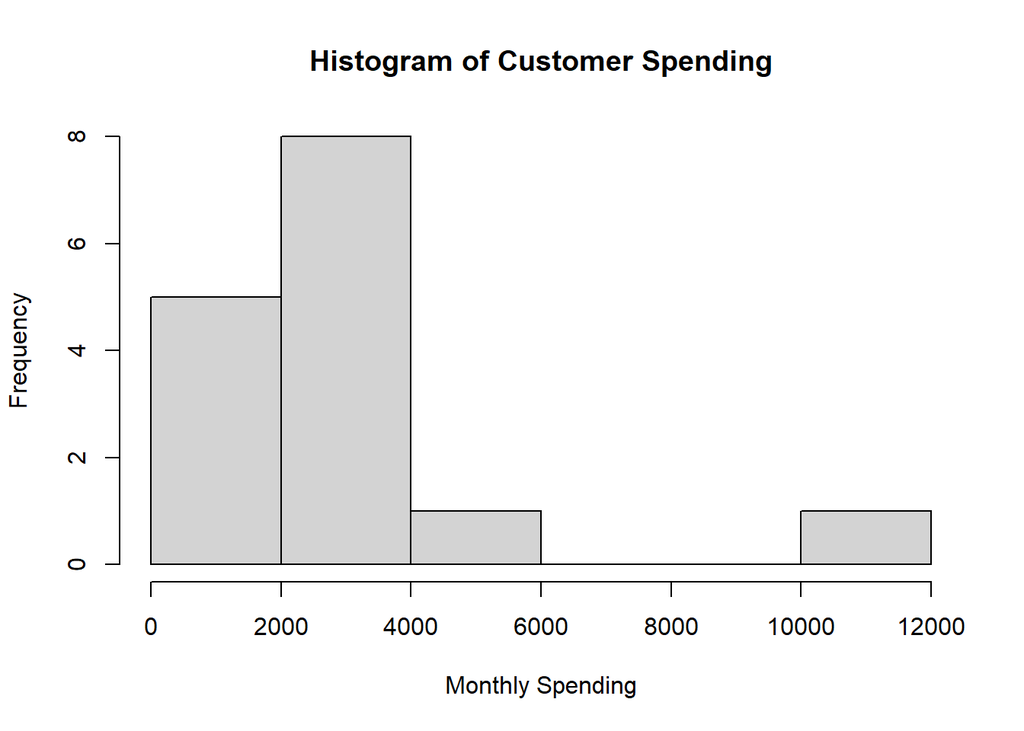

```r
hist(
  spending,
  main = "Histogram of Customer Spending",
  xlab = "Monthly Spending"
)
```

### Boxplot

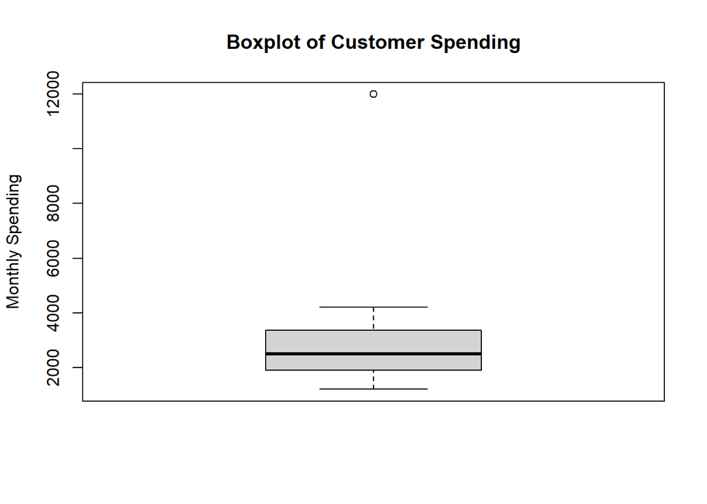

```r
boxplot(
  spending,
  main = "Boxplot of Customer Spending",
  ylab = "Monthly Spending"
)
```

### Dot Plot

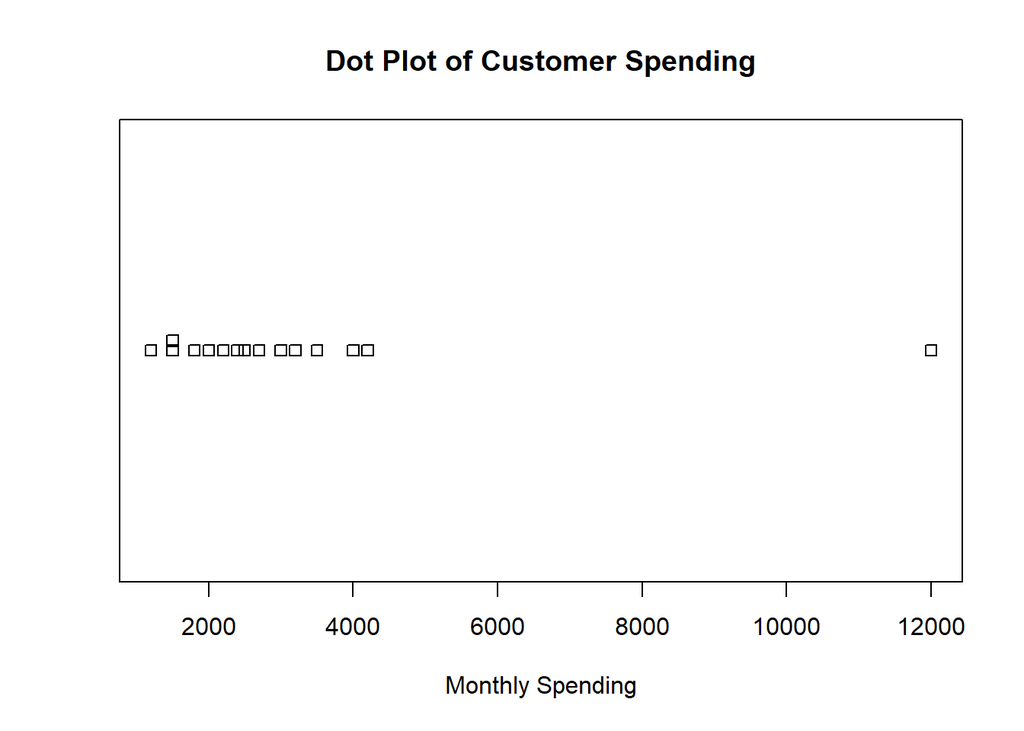

```r
stripchart(
  spending,
  method = "stack",
  main = "Dot Plot of Customer Spending",
  xlab = "Monthly Spending"
)
```

### Bar Graph for Categorical Data

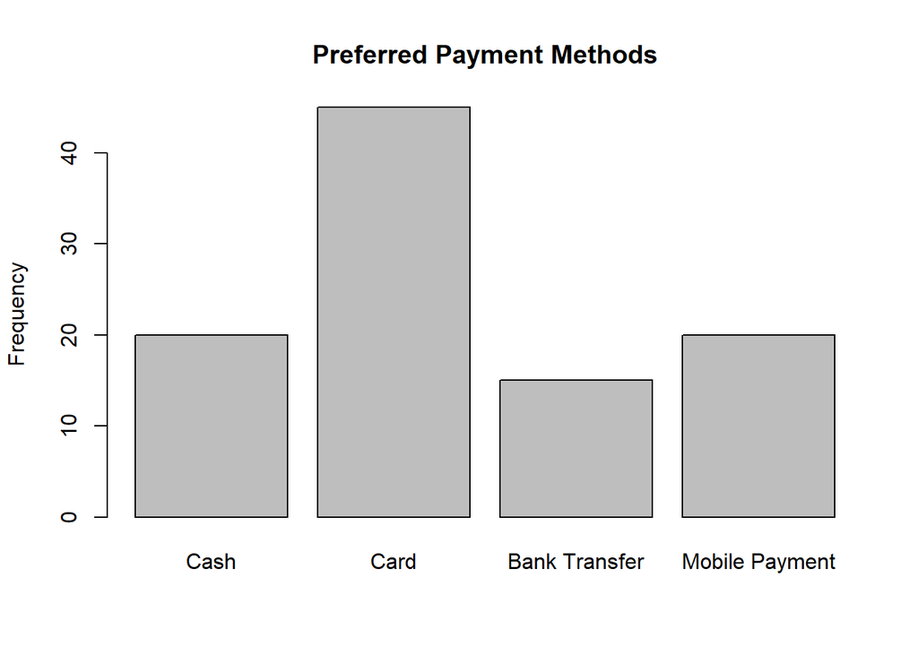

```r
payment_method <- c("Cash", "Card", "Bank Transfer", "Mobile Payment")
frequency <- c(20, 45, 15, 20)

barplot(
  frequency,
  names.arg = payment_method,
  main = "Preferred Payment Methods",
  ylab = "Frequency"
)
```

### Pie Chart

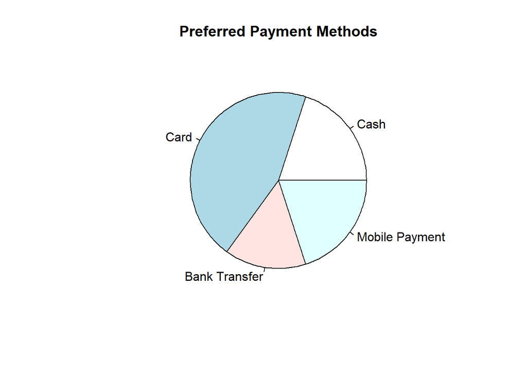

```r
pie(
  frequency,
  labels = payment_method,
  main = "Preferred Payment Methods"
)
```

### Line Graph

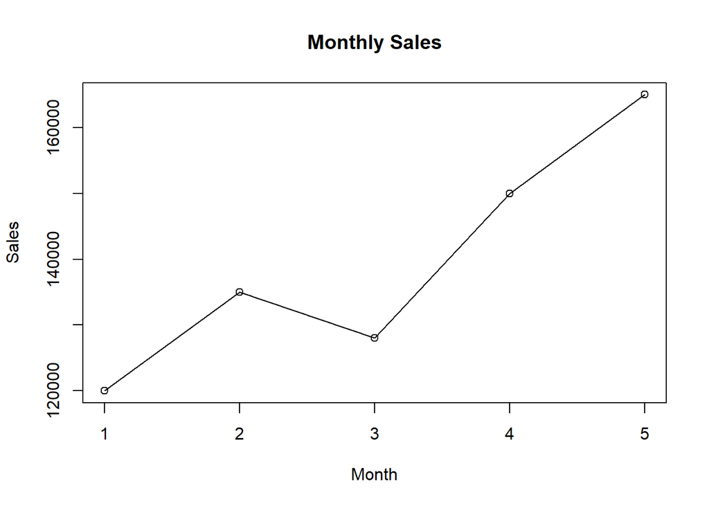

```r
month <- 1:5
sales <- c(120000, 135000, 128000, 150000, 165000)

plot(
  month,
  sales,
  type = "o",
  main = "Monthly Sales",
  xlab = "Month",
  ylab = "Sales"
)
```

### Ogive

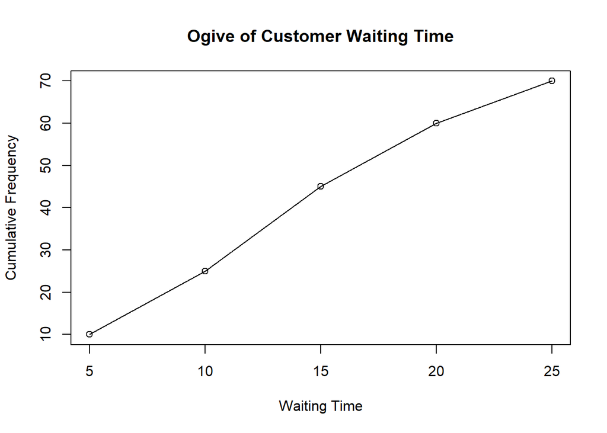

```r
waiting_time <- c(5, 10, 15, 20, 25)
cumulative_frequency <- c(10, 25, 45, 60, 70)

plot(
  waiting_time,
  cumulative_frequency,
  type = "o",
  main = "Ogive of Customer Waiting Time",
  xlab = "Waiting Time",
  ylab = "Cumulative Frequency"
)
```

## Practical Closing Note for Students

Descriptive statistics is not only about producing numbers and graphs.

A good data analyst should be able to explain what those numbers and graphs mean in real life.

is not enough.

That is the type of interpretation expected in data science and business analytics.